# Project One: Environmental Analysis

# Data overview

To place figures in the margin you can use the **knitr** chunk option `fig.margin = TRUE`.

For example:

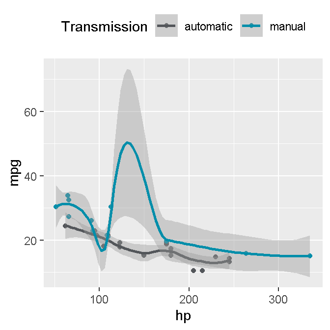

**FIG 1.** MPG vs horsepower, colored by transmission.

```r
library(ggplot2)
library(mncolors)

mtcars <- mtcars

mtcars$Transmission <- factor(mtcars$am,
                              labels = c('automatic', 'manual'))

ggplot(mtcars, aes(hp, mpg, color = Transmission)) +
  geom_point() +
  geom_smooth() +
  scale_color_mn(palette = "accent", reverse = T) +
  theme(legend.position = 'top')
```

## MN Colors

You can set the colors for your plots to align with the MN state brand:

[figure not shown]

```r
library(mncolors) #remotes::install_github("MPCA-data/mncolors")
library(ggplot2)
library(hrbrthemes)

mpca_theme <- function() {

  title_color   <- mncolors(5, "blue")[5]

  caption_color <- mncolors(5, "blue")[2]

  theme_ipsum_rc() +
       theme(plot.title   = element_text(color = title_color),
             plot.caption = element_text(color = caption_color, face  = 'bold'))

}

ggplot(diamonds, aes(carat, price)) +
  geom_smooth(aes(color = cut), size = 1.5, show.legend = F) +
  scale_color_mn(palette = "treefrog") +
  facet_wrap(vars(cut), nrow = 1) +
  labs(title    = "Increasing cost of cleanups",
       subtitle = "Brownfield site classifications",
       caption  = "Source: EPA Data Mart 2018") +
  scale_y_comma() +
  mpca_theme()
```